# Case Study 1: Give your Visualization Wings to Fly

Devin Harp

January 29, 2022

## Background

“On-time data for all flights that departed NYC (i.e. JFK, LGA or EWR) in 2013.” - ?flights

You just started your internship at a big firm in New York, and your manager gave you an extensive file of flights that departed JFK, LGA, or EWR in 2013. From this data (which you can obtain in R) your manager wants you to answer the following questions:

1. If I am leaving before noon, which two airlines do you recommend at each airport (JFK, LGA, EWR) that will have the lowest delay time at the 75th percentile?
2. Which origin airport is best to minimize my chances of a late arrival when I am using Delta Airlines?
3. Which destination airport is the worst airport for arrival time? You decide on the metric for “worst.”

## Data Wrangling

```r
# Question 1
q1 <- flights %>%
  na.omit() %>%
  select(carrier, sched_dep_time, dep_delay, origin) %>%
  filter(origin %in% c("JFK", "LGA", "EWR")) %>%
  filter(sched_dep_time < 1200) %>%
  filter(carrier != "OO") %>%
  group_by(carrier, origin) %>%
  summarise(Q3 = quantile(dep_delay, 0.75))

# Question 2
q2 <- flights %>%
  na.omit() %>%
  select(carrier, arr_time, sched_arr_time, arr_delay, origin) %>%
  filter(carrier == "DL")

# Question 3
# count(flights, dest) = 95+ results
q3 <- flights %>%
  na.omit() %>%
  select(dest, arr_delay) %>%
  group_by(dest) %>%
  summarise(median = median(arr_delay)) %>%
  filter(median > 0)
```

## Data Visualization

### Question 1

“If I am leaving before noon, which two airlines do you recommend at each airport (JFK, LGA, EWR) that will have the lowest delay time at the 75th percentile?”

*(Each carrier who had a value of 0 for the origin airport was removed from their respective facet. This assumes the client is interested in carriers that have earlier departures rather than later)*

For carriers departing before noon (> 1200), you may find their 75th quartile value represented by the graphs split into the three originating airport groups. For EWR, 9E and US airlines are the best pick as their 75th quartile is -2, meaning 75% of the rest of the times of departure we have on record lie below that threshold meaning you will most likely depart earlier than expected.

For JFK, DL and HA are the best considerations and for LGA, you have US exceeding all the others with the option of either AA, B6, DL, and YV.

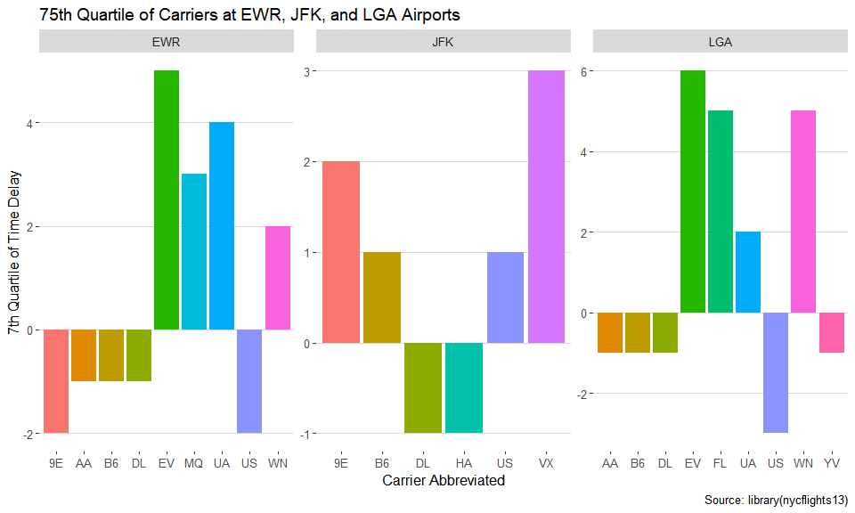

```r
q1 <- q1 %>%
  filter(Q3 != 0)

ggplot(q1) +
  facet_wrap(~ origin, scales = "free") +
  geom_col(aes(x = carrier, y = Q3, fill = carrier), show.legend = FALSE) +
  labs(x = "Carrier Abbreviated", y = "7th Quartile of Time Delay", title = "75th Quartile of Carriers at EWR, JFK, and LGA Airports", caption = "Source: library(nycflights13)") +
  theme_hc()
```

### Question 2

“Which origin airport is best to minimize my chances of a late arrival when I am using Delta Airlines?”

*(Set values for arrival delay between -50 and 70 to focus on the main grouping)*

Taking in all the individual flight data for Delta Airlines from the 3 originating airports and their arrival delays, determining which originating airport is best to minimize chance of a late arrival is more nuanced. LGA seems to have more flights than the others and therefore experiences greater disparity between arrivals that come in earlier or later while the other two seem more concentrated. However, LGA has the strongest proportion of earlier arrivals than the others while the later ones seem less common, making LGA a better choice in the end with some risk.

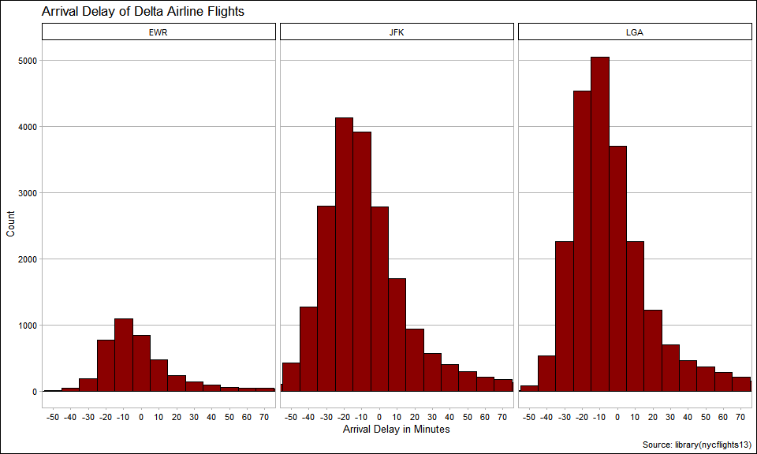

```r
ggplot(q2) +
  facet_wrap(~ origin ) +
  geom_histogram(aes(x = arr_delay), binwidth = 10, fill = "darkred", color = "black") +
  scale_x_continuous(breaks = seq(-50, 70, 10)) +
  coord_cartesian(xlim = c(-50, 70)) +
  labs(x = "Arrival Delay in Minutes", y = "Count", title = "Arrival Delay of Delta Airline Flights", caption = "Source: library(nycflights13)") +
  theme_calc()
```

### Question 3

“Which destination airport is the worst airport for arrival time? You decide on the metric for ‘worst.’”

Because of the heavily skewed data, we will use median as a method of measuring what constitutes the worst airport.

CAE compared to other airports with a median greater than 0 has the worst median arrival delay of all the available destination airports from the dataset. This means that half the data lies below and above its median value which is 28.

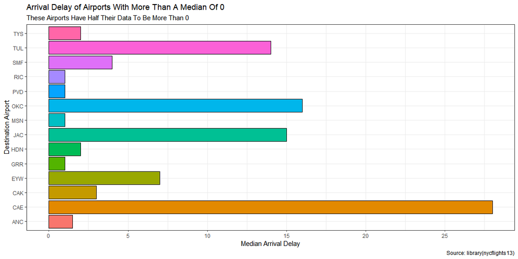

```r
ggplot(q3) +
  geom_col(aes(x = median, y = dest, fill = dest), color = "black", show.legend = FALSE) +
  scale_x_continuous(breaks = seq(0, 30, 5)) +
  labs(x = "Median Arrival Delay", y = "Destination Airport", title = "Arrival Delay of Airports With More Than A Median Of 0", subtitle = "These Airports Have Half Their Data To Be More Than 0", caption = "Source: library(nycflights13)") +
  theme_bw()
```